# Question 2

# Has music gotten louder over time?

## Introduction

Music can be considered a defining characteristic of a generation. The most popular songs of a decade often reflect the general culture, philosophy, and sentiment of that time. For this reason, our second question set out to examine how popular music has changed over time on a decade-by-decade basis. Specifically, we set out to see what variables have most drastically changed over time, and whether identifying these changes might be informative with respect to trends in culture popular culture. After some exploratory analysis, hypothesis testing was conducted on mean differences in track loudness over the decades using pairwise t-tests and ANOVA.

## Methodology

### Data Gathering

The first step in the process was to gather appropriate data to explore. Spotify maintains a playlist for each decade from 1950 to 2010 entitled “All out” followed by the decade. These playlists reflect the most popular songs from that decade in the United States. While Spotify is not transparent about their sampling method for the playlist, it is assumed that these playlists are based on the top charts from each decade. The current decade was also included for continuity, and in this case the spotify “top tracks” playlists were used for each year of the decade thus far (2020, 2021, 2022). All data were gathered from the Spotify API, using the SpotifyR package.

### Data cleaning

The dataset was checked for missing values and duplicate song names. No missing values were detected and any duplicate songs were removed. Only non-categorical (continuous) track features were considered in the analysis since the planned hypothesis tests were only suitable for numerical data. Track identifiers were omitted. Popularity was dropped as a variable since all songs in the analysis were retrieved from top charts. After these steps were applied, the final dataset contained 9 features, one categorical decade label, and 1,329 songs (10 x 1329 matrix).

### Exploratory data analysis (EDA)

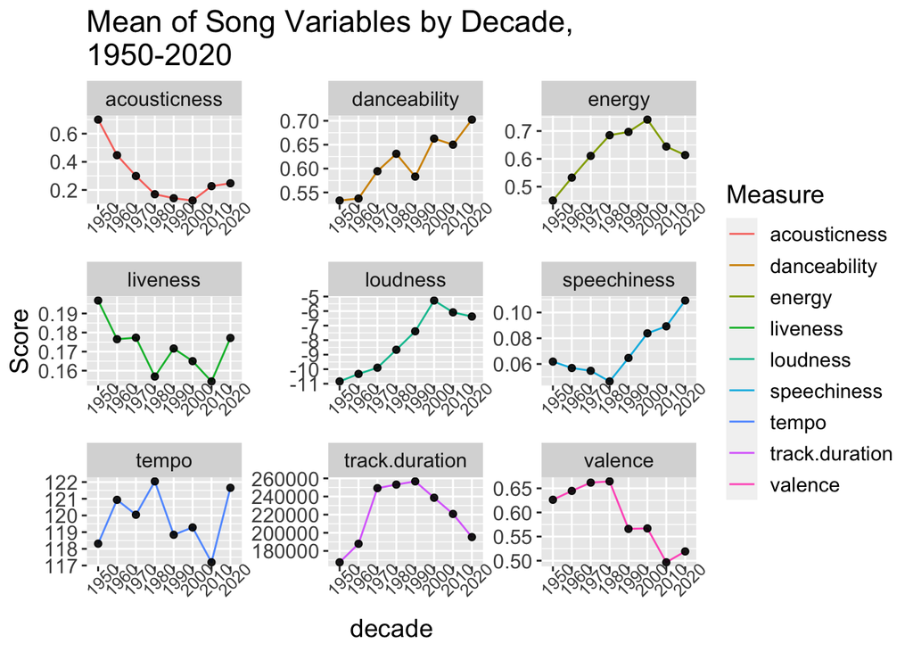

```r
library(tidyverse)
library(viridis)

# Read in data
decades <- read_csv("spotify_decades.csv") %>% rename(decade = tag)

# Pivot for suitable graphing with facets
songs_long <- decades %>% pivot_longer(cols = colnames(decades)[5:14], names_to = "Measure",
                                values_to = "Score") %>% mutate(decade = as.factor(decade))

# Discard instrumentalness (little variance)
songs_long <- songs_long[songs_long$Measure!="instrumentalness",]

# Graph overall trends
mean_data <- songs_long %>% group_by(decade, Measure) %>%
  summarise(across(.cols = Score, .fns = mean))

# Rename track duration
mean_data[mean_data$Measure=="track.duration_ms",]$Measure <- "track.duration"

# Graph trend
mean_data %>%
  ggplot(aes(x = decade, y = Score)) + facet_wrap(~Measure, scales = "free", nrow = 3) +
  geom_line(aes(group = 1, color = Measure)) + geom_point(alpha = .9, color = "black") +
  labs(title = "Mean of Song Variables by Decade,\n1950-2020") +
  theme(text = element_text(size = 14), axis.text.x = element_text(
                           size=9.5, angle=45))
```

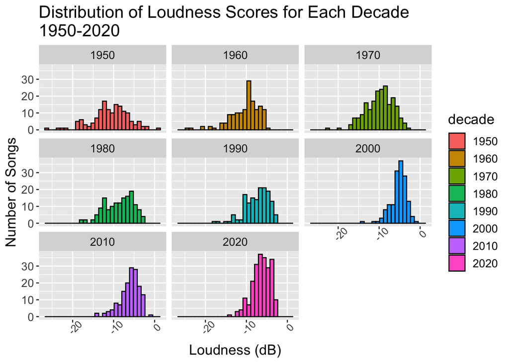

```r
# Distribution of loudness for each decade
decades %>% mutate(decade = as.factor(decade)) %>%
  ggplot(aes(x = loudness)) + facet_wrap(~decade) + geom_histogram(aes(fill = decade), color = "black") +
  labs(title = "Distribution of Loudness Scores for Each Decade\n1950-2020", x = "Loudness (dB)",
       y = "Number of Songs") + theme(text = element_text(size = 14), axis.text.x = element_text(
                           size=10, angle=45))
```

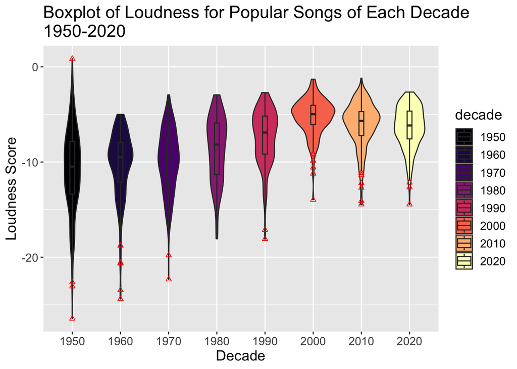

```r
# Violin plot of loudness for each decade
decades %>% mutate(decade = as.factor(decade)) %>% ggplot(aes(decade, loudness)) +
  geom_violin(aes(group = decade, fill = decade)) +
  geom_boxplot(aes(group = decade, fill = decade), outlier.colour = "red",
               outlier.shape = 2, width=0.1) + labs(title = "Boxplot of Loudness for Popular Songs of Each Decade\n1950-2020",
                                         x = "Decade", y = "Loudness Score") +
  scale_fill_viridis(discrete = T, option = "magma") + theme(text = element_text(size = 14))
```

Distributions and mean for each variable were visualized in a ggplot facet grid. Based on the EDA, one of the clearest trends identified in the plot above is in the loudness variable. For this reason, loudness was selected as the first variable to be analyzed. The distribution of each decade’s loudness score (in decibels) was also plotted to determine its suitability for parametric hypothesis tests. Each decade’s loudness distribution appeared approximately gaussian, and we proceeded with the parametric hypothesis tests since they are robust to moderate deviations from normality.

### Analysis of Variance

After EDA, we conducted an analysis of variance (ANOVA) test on the loudness scores of each decade. An ANOVA is a univariate test to determine whether a variable is different under the conditions of a categorical variable. This test will help us determine whether, in general, there is a difference in mean loudness among the decade groups, however it will not inform us specifically as to the directionality of the difference or which decades differ specifically. The null and alternative hypothesis are as follows:

$H_0: \mu_{1950} = \mu_{1960} = \mu_{1970} = \mu_{1980} = \mu_{1990} = \mu_{2000} = \mu_{2010} = \mu_{2020}$, there is no difference in mean loudness scores among the decades.

$H_a:$ The mean loudness scores are not equal.

```r
# Anova for loudness
summary(aov(loudness ~ decade, data = decades))
```

```
##               Df Sum Sq Mean Sq F value Pr(>F)
## decade         1   4394    4394   436.4 <2e-16 ***
## Residuals   1327  13360      10
## ---
## Signif. codes:  0 '***' 0.001 '**' 0.01 '*' 0.05 '.' 0.1 ' ' 1
```

### Pairwise t-tests

#### A note on multiple comparisons

The next step in our analysis was to determine which decades had mean loudness scores that significantly differed from each other. To this effect, we decided to conduct pairwise t-tests on the loudness scores between each decade to determine which decades are different from one another. Since there are 8 decades available to us, the number of pairwise t-tests required was:

$C(8,2) = \frac{8!}{2!(8-2)!} = 28$

$H_0: \mu_x = \mu_y$ There is no difference in mean loudness scores for some decade X and decade Y - the difference in means is zero. In other words, both decade X and decade Y have similar loudness scores for their tracks on average.

$H_a: \mu_x \neq \mu_y$ The difference in mean loudness scores for some decade X and decade Y are not zero. In other words, decade X and decade Y have different loudness levels on their most popular tracks on average.

#### Results/Conclusion

```r
library(ggpubr)
library(rstatix)
```

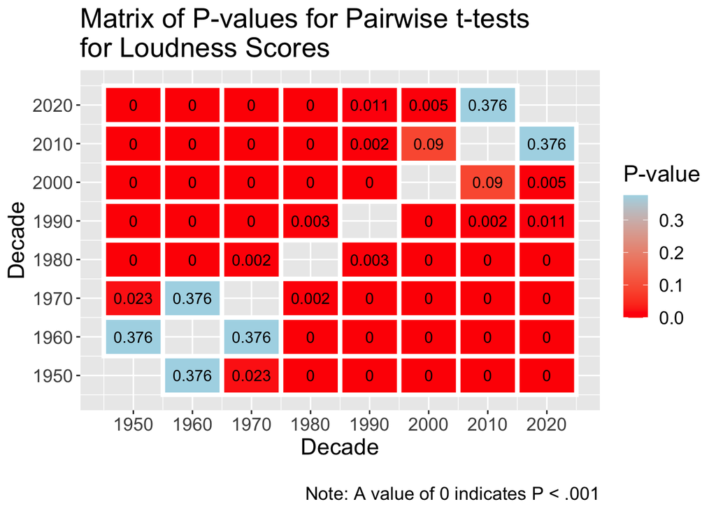

```r
library(viridis)
# Pairwise t-tests for loudness - Hochberg correction
loud.test <- pairwise_t_test(decades, loudness ~ decade, paired = F,
                p.adjust.method = "hochberg")

# Pairwise t-test matrix
loud.test2 <- pairwise.t.test(decades$loudness, decades$decade,
                             p.adjust.method = "hochberg")

# Heat map of p-values
# Heatmap with t-test results
loud.data <- reshape2::melt(loud.test2$p.value) %>% mutate(value = round(value, 3))
loud.data <- na.omit(loud.data)
loud.data2 <- data.frame(Var1 = loud.data$Var2, Var2 = loud.data$Var1, value = loud.data$value)
loud.matrix <- bind_rows(loud.data, loud.data2)

loud.matrix %>% ggplot(aes(Var1, Var2, fill = value)) + geom_tile(color = "white",
            lwd = 1.5,
            linetype = 1) +
  geom_text(aes(label = value)) +
  scale_x_continuous(breaks = seq(1950, 2020, 10)) +
  scale_y_continuous(breaks = seq(1950, 2020, 10)) + labs(title = "Matrix of P-values for Pairwise t-tests\nfor Loudness Scores",
                                                          x = "Decade", y = "Decade",
                                                          caption = "\nNote: A value of 0 indicates P < .001",
                                                          ) +
  scale_fill_gradient("P-value", low = "red", high = "lightblue") + theme(text = element_text(size = 16))
```

The results of our pairwise t-tests suggest that for many decades, there is a significant difference in loudness of popular songs. Specifically, from the years 1970-2000, there is a significant increase in loudness score for the most popular tracks. There is not as much of significant difference in loudness on the lower and upper range, however. For example, there is no significant difference in loudness from 1950 to 1960, 1960 to 1970, and 2010 to 2020. Notably, between 2000 and 2020, there is a significant difference in loudness for popular songs in the other direction - the loudness has decreased on average. Overall, this suggests a trend in popular music where songs have generally increased in volume on average from the period 1950-2000, and have begun to decrease in the period 2000-2020.

## Sources

Benjamini, Y., & Hochberg, Y. (2000). On the adaptive control of the false discovery rate in multiple testing with independent statistics. Journal of educational and Behavioral Statistics, 25(1), 60-83.

Jafari, M., & Ansari-Pour, N. (2019). Why, when and how to adjust your P values?. Cell Journal (Yakhteh), 20(4), 604.